# ManojNair_Meenakshi_FinalProject

# Introduction

Unemployment is one of the most important indicators of a country’s economic and social well-being, and analyzing how it changes over time can provide insight into broader global and national trends. For this project, I examine unemployment patterns using multiple datasets collected from Kaggle and the International Labour Organization (ILOSTAT), focusing on both global trends and detailed U.S. unemployment indicators. By exploring unemployment rates, economic variables, and demographic breakdowns from 1991 to 2023, the goal of this project is to understand how unemployment varies across countries, how it has shifted over the years, and what factors may be associated with these changes. This project emphasizes exploratory data analysis and visualization to identify meaningful patterns rather than prediction or statistical modeling.

# Data

```r
# Importing libraries
library(tidyverse)
library(lubridate)

# Importing your datasets
unemployment <- read.csv("UNE_TUNE_SEX_AGE_MTS_NB_A-filtered-2025-12-03.csv")
gdp <- read.csv("Employment_Unemployment_GDP_data.csv")
trend <- read.csv("job_market_unemployment_trends.csv")
```

```r
# EDA
colnames(unemployment)
```

```
##  [1] "ref_area.label"       "source.label"         "indicator.label"
##  [4] "sex.label"            "classif1.label"       "classif2.label"
##  [7] "time"                 "obs_value"            "obs_status.label"
## [10] "note_classif.label"   "note_indicator.label" "note_source.label"
```

```r
colnames(gdp)
```

```
## [1] "Country.Name"                   "Year"
## [3] "Employment.Sector..Agriculture" "Employment.Sector..Industry"
## [5] "Employment.Sector..Services"    "Unemployment.Rate"
## [7] "GDP..in.USD."
```

```r
colnames(trend)
```

```
## [1] "id"                        "date"
## [3] "location"                  "unemployment_rate"
## [5] "job_postings"              "in_demand_skills"
## [7] "average_age"               "college_degree_percentage"
```

```r
unemp_clean <- unemployment %>%
  rename(
    country = ref_area.label,
    source = source.label,
    indicator = indicator.label,
    sex = sex.label,
    age_group = classif1.label,
    year = time,
    unemployment_thousands = obs_value
  ) %>%
  filter(country == "United States of America") %>%
  mutate(
    age_group = as.factor(age_group),
    sex = as.factor(sex)
  )

gdp_clean <- gdp %>%
  rename(
    country = Country.Name,
    year = Year,
    agri_emp = Employment.Sector..Agriculture,
    industry_emp = Employment.Sector..Industry,
    services_emp = Employment.Sector..Services,
    unemployment_rate = Unemployment.Rate,
    gdp_usd = GDP..in.USD.
  ) %>%
  mutate(
    year = as.numeric(year),
    agri_emp = as.numeric(agri_emp),
    industry_emp = as.numeric(industry_emp),
    services_emp = as.numeric(services_emp),
    unemployment_rate = as.numeric(unemployment_rate),
    gdp_usd = as.numeric(gdp_usd)
  ) %>%
  drop_na(unemployment_rate, gdp_usd) %>%
  distinct()

trend_clean <- trend %>%
  rename(
    region = location,
    unemployment_rate = unemployment_rate,
    job_postings = job_postings,
    skills = in_demand_skills,
    avg_age = average_age,
    college_pct = college_degree_percentage
  ) %>%
  mutate(
    date = as.Date(date),
    unemployment_rate = as.numeric(unemployment_rate),
    job_postings = as.numeric(job_postings),
    avg_age = as.numeric(avg_age),
    college_pct = as.numeric(college_pct),
    skills = as.character(skills)
  ) %>%
  drop_na(unemployment_rate) %>%
  distinct()
```

```r
## Basic summary  & Structure
str(unemp_clean)
```

```
## 'data.frame':    4224 obs. of  12 variables:
##  $ country               : chr  "United States of America" "United States of America" "United States of America" "United States of America" ...
##  $ source                : chr  "LFS - Current Population Survey" "LFS - Current Population Survey" "LFS - Current Population Survey" "LFS - Current Population Survey" ...
##  $ indicator             : chr  "Unemployment by sex, age and marital status (thousands)" "Unemployment by sex, age and marital status (thousands)" "Unemployment by sex, age and marital status (thousands)" "Unemployment by sex, age and marital status (thousands)" ...
##  $ sex                   : Factor w/ 3 levels "Female","Male",..: 3 3 3 3 3 3 3 3 3 3 ...
##  $ age_group             : Factor w/ 16 levels "Age (10-year bands): 15-24",..: 15 15 15 14 14 14 13 13 13 16 ...
##  $ classif2.label        : chr  "Marital status (Aggregate): Total" "Marital status (Aggregate): Single / Widowed / Divorced" "Marital status (Aggregate): Married / Union / Cohabiting" "Marital status (Aggregate): Total" ...
##  $ year                  : int  2024 2024 2024 2024 2024 2024 2024 2024 2024 2024 ...
##  $ unemployment_thousands: num  6761 4798 1963 6397 4606 ...
##  $ obs_status.label      : chr  "" "" "" "" ...
##  $ note_classif.label    : chr  "" "" "" "Nonstandard age group: Excluding age 15" ...
##  $ note_indicator.label  : chr  "" "" "" "" ...
##  $ note_source.label     : chr  "Repository: ILO-STATISTICS - Micro data processing | Age coverage - minimum age: 16 years old" "Repository: ILO-STATISTICS - Micro data processing | Age coverage - minimum age: 16 years old" "Repository: ILO-STATISTICS - Micro data processing | Age coverage - mini…
```

```r
str(gdp_clean)
```

```
## 'data.frame':    5751 obs. of  7 variables:
##  $ country          : chr  "Albania" "Algeria" "Angola" "Argentina" ...
##  $ year             : num  1991 1991 1991 1991 1991 ...
##  $ agri_emp         : num  53.3 24.1 40.1 13.7 54.3 ...
##  $ industry_emp     : num  12.17 25.07 8.16 28.51 15.79 ...
##  $ services_emp     : num  34.5 50.8 51.8 57.8 29.9 ...
##  $ unemployment_rate: num  10.3 20.6 16.86 5.44 1.78 ...
##  $ gdp_usd          : num  1.10e+09 4.57e+10 1.06e+10 1.90e+11 2.07e+09 ...
```

```r
str(trend_clean)
```

```
## 'data.frame':    1000 obs. of  8 variables:
##  $ id               : int  1 2 3 4 5 6 7 8 9 10 ...
##  $ date             : Date, format: "2023-10-07" "2025-05-24" ...
##  $ region           : chr  "Houston" "Washington" "Chicago" "Indianapolis" ...
##  $ unemployment_rate: num  6.8 11.1 7.3 11.2 13.7 5 13.7 10.1 9 12.4 ...
##  $ job_postings     : num  4894 2695 1174 3708 268 ...
##  $ skills           : chr  "Agile Methodologies, Project Management" "Data Analysis, UX/UI Design, Digital Marketing" "Agile Methodologies, Digital Marketing, Machine Learning, Cloud Computing, Cybersecurity" "Cloud Computing, UX/UI Design" ...
##  $ avg_age          : num  44 50 48 36 41 37 33 34 30 39 ...
##  $ college_pct      : num  74 87 54 75 75 52 38 44 68 44 ...
```

```r
colSums(is.na(unemp_clean))
```

```
##                country                 source              indicator
##                      0                      0                      0
##                    sex              age_group         classif2.label
##                      0                      0                      0
##                   year unemployment_thousands       obs_status.label
##                      0                     66                      0
##     note_classif.label   note_indicator.label      note_source.label
##                      0                      0                      0
```

```r
colSums(is.na(gdp_clean))
```

```
##           country              year          agri_emp      industry_emp
##                 0                 0                 0                 0
##      services_emp unemployment_rate           gdp_usd
##                 0                 0                 0
```

```r
colSums(is.na(trend_clean))
```

```
##                id              date            region unemployment_rate
##                 0                 0                 0                 0
##      job_postings            skills           avg_age       college_pct
##                 0                 0                 0                 0
```

```r
## Summary Statistics
summary(unemp_clean$unemployment_rate)
```

```
## Length  Class   Mode
##      0   NULL   NULL
```

```r
summary(gdp_clean$unemployment_rate)
```

```
##    Min. 1st Qu.  Median    Mean 3rd Qu.    Max.
##   0.100   3.659   6.358   8.155  10.996  38.800
```

```r
summary(trend_clean$unemployment_rate)
```

```
##    Min. 1st Qu.  Median    Mean 3rd Qu.    Max.
##    2.00    5.40    8.80    8.63   11.80   15.00
```

```r
## Top 10 Countries with Highest Average Unemployment
gdp_clean %>%
  group_by(country) %>%
  summarize(avg_unemp = mean(unemployment_rate, na.rm = TRUE)) %>%
  arrange(desc(avg_unemp)) %>%
  slice_head(n = 10)
```

| country | avg_unemp |
| --- | --- |
| North Macedonia | 29.42306 |
| Djibouti | 26.52287 |
| Eswatini | 25.58528 |
| South Africa | 24.55047 |
| Bosnia and Herzegovina | 23.50022 |
| Montenegro | 22.39992 |
| Namibia | 20.95144 |
| Congo, Rep. | 20.07494 |
| St. Vincent and the Grenadines | 19.76350 |
| West Bank and Gaza | 19.63797 |

# VISUALISATION

## 1. GLOBAL DATASET

The global unemployment trend shows noticeable increases during major global shocks, including the 2008 financial crisis and the COVID-19 pandemic around 2020. Although unemployment decreases after these periods, it does not always return to pre-crisis levels, suggesting uneven global recovery.

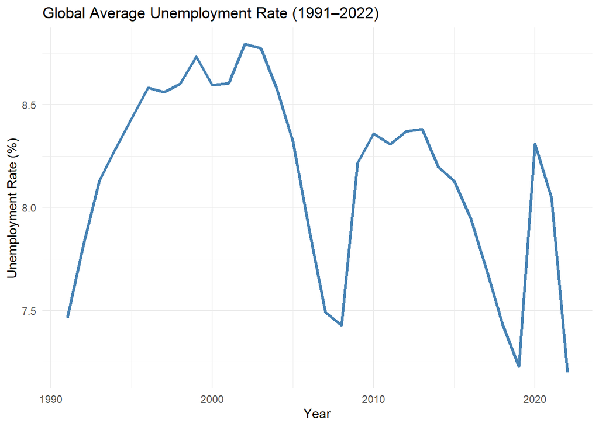

```r
### Global Unemployment Trend Over Time
gdp_clean %>%
  group_by(year) %>%
  summarize(global_unemp = mean(unemployment_rate, na.rm = TRUE)) %>%
  ggplot(aes(year, global_unemp)) +
  geom_line(color = "steelblue", size = 1.1) +
  labs(
    title = "Global Average Unemployment Rate (1991–2022)",
    x = "Year",
    y = "Unemployment Rate (%)"
  ) +
  theme_minimal()
```

This visualization explores how global unemployment has changed from 1991 to 2022. A line plot is the best method here because it clearly shows changes over time and highlights long-term patterns. By averaging unemployment across all countries each year, we can observe major economic events reflected in the data. The results show noticeable rises around global crises such as the 2008 recession and the COVID-19 pandemic, followed by gradual recovery periods. This trend helps us understand how sensitive global employment is to economic shocks.

The GDP vs unemployment scatterplot shows a mild negative relationship: countries with higher GDP levels tend to have lower unemployment rates. However, the points are widely spread, indicating that GDP alone does not fully explain labor-market differences across countries.

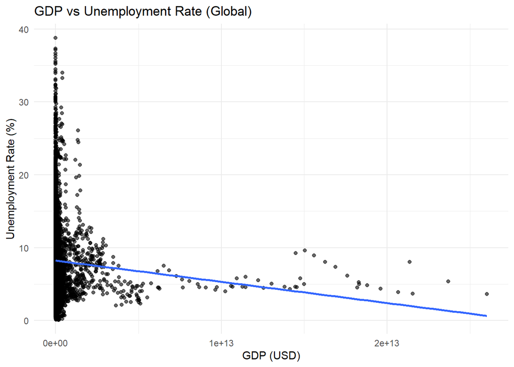

```r
### GDP vs Unemployment Rate
gdp_clean %>%
  ggplot(aes(x = gdp_usd, y = unemployment_rate)) +
  geom_point(alpha = 0.6) +
  geom_smooth(method = "lm", se = FALSE, linewidth = 1) +
  labs(
    title = "GDP vs Unemployment Rate (Global)",
    x = "GDP (USD)",
    y = "Unemployment Rate (%)"
  ) +
  theme_minimal()
```

This scatter plot examines whether countries with higher GDP tend to have lower unemployment, a common economic assumption. A scatterplot with a fitted linear trend is chosen because it allows us to study general relationships and detect any correlation. The results show a weak negative relationship, meaning richer countries often—but not always—have lower unemployment. Many low-GDP countries show high unemployment, while high-GDP countries vary. This visualization reveals that economic output alone does not fully explain unemployment differences across nations.

The correlation coefficient quantifies the strength and direction of the relationship between GDP and unemployment. A negative value would confirm that higher GDP levels are associated with lower unemployment rates.

```r
### Correlation Between GDP and Unemployment
# Correlation (Global)
correlation_gdp_unemp <- cor(
  gdp_clean$gdp_usd,
  gdp_clean$unemployment_rate,
  use = "complete.obs"
)

correlation_gdp_unemp
```

```
## [1] -0.06515394
```

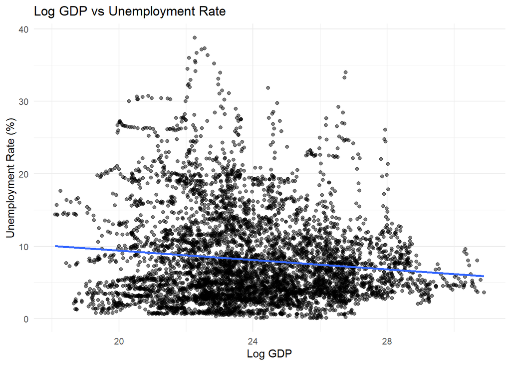

```r
### Log Transformation of GDP
gdp_clean <- gdp_clean %>%
  mutate(log_gdp = log(gdp_usd))

ggplot(gdp_clean, aes(log_gdp, unemployment_rate)) +
  geom_point(alpha = 0.5) +
  geom_smooth(method = "lm", se = FALSE) +
  labs(
    title = "Log GDP vs Unemployment Rate",
    x = "Log GDP",
    y = "Unemployment Rate (%)"
  ) +
  theme_minimal()
```

Because GDP values vary widely across countries, a log transformation reduces skewness and allows a clearer view of the linear relationship between economic output and unemployment.

```r
### Linear Regression Model
model <- lm(unemployment_rate ~ log_gdp, data = gdp_clean)
summary(model)
```

```
##
## Call:
## lm(formula = unemployment_rate ~ log_gdp, data = gdp_clean)
##
## Residuals:
##    Min     1Q Median     3Q    Max
## -8.852 -4.352 -1.543  2.935 30.102
##
## Coefficients:
##             Estimate Std. Error t value Pr(>|t|)
## (Intercept) 15.90372    0.85195  18.667   <2e-16 ***
## log_gdp     -0.32373    0.03543  -9.136   <2e-16 ***
## ---
## Signif. codes:  0 '***' 0.001 '**' 0.01 '*' 0.05 '.' 0.1 ' ' 1
##
## Residual standard error: 6.104 on 5749 degrees of freedom
## Multiple R-squared:  0.01431,    Adjusted R-squared:  0.01414
## F-statistic: 83.47 on 1 and 5749 DF,  p-value: < 2.2e-16
```

The regression model estimates the effect of GDP (log-transformed) on unemployment rates. The coefficient shows the direction of association, while the R-squared value indicates how much variation in unemployment is explained by GDP alone.

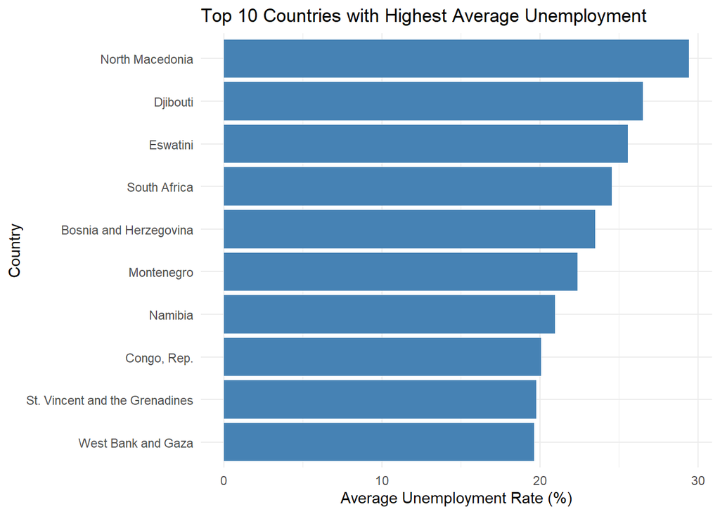

```r
### Top 10 Countries with Highest Average Unemployment
gdp_clean %>%
  group_by(country) %>%
  summarize(avg_unemp = mean(unemployment_rate, na.rm = TRUE)) %>%
  arrange(desc(avg_unemp)) %>%
  slice_head(n = 10) %>%
  ggplot(aes(x = reorder(country, avg_unemp), y = avg_unemp)) +
  geom_col(fill = "steelblue") +
  coord_flip() +
  labs(
    title = "Top 10 Countries with Highest Average Unemployment",
    x = "Country",
    y = "Average Unemployment Rate (%)"
  ) +
  theme_minimal()
```

This bar chart highlights the countries with the highest unemployment rates across the dataset. Bar charts are ideal for ranking comparisons, allowing a quick and intuitive understanding of which regions face the greatest labor market challenges. The results show that several countries consistently struggle with unemployment over long periods, reflecting structural problems such as political instability, weak economic growth, or limited industrial diversification. This visualization shows how unemployment burden is unevenly distributed globally.

This code selects the three employment sector variables — agriculture, industry, and services — and produces a basic summary of each. The summary() function gives the minimum, 1st quartile, median, mean, 3rd quartile, and maximum values. This helps us understand the overall distribution of employment shares across countries and years, including how high or low each sector’s employment percentage can be. It provides a quick overview of the structural composition of labor markets before doing any detailed visualization.

```r
### Employment Sector Distribution (Agriculture, Industry, Services)
gdp_clean %>%
  select(agri_emp, industry_emp, services_emp) %>%
  summary()
```

```
##     agri_emp        industry_emp    services_emp
##  Min.   : 0.1078   Min.   : 2.06   Min.   : 5.314
##  1st Qu.: 7.1732   1st Qu.:13.89   1st Qu.:36.847
##  Median :22.1721   Median :20.11   Median :52.658
##  Mean   :28.8571   Mean   :19.77   Mean   :51.369
##  3rd Qu.:46.1307   3rd Qu.:25.35   3rd Qu.:66.602
##  Max.   :92.4820   Max.   :59.58   Max.   :93.417
```

This summary provides a global snapshot of employment distribution across agriculture, industry, and services. A statistical summary is used instead of a plot because the goal is to understand the overall distribution rather than compare specific countries. The results show that the services sector dominates globally, averaging about 51% of total employment. Agriculture varies widely, ranging from less than 1% to over 90%, reflecting differences in development levels. Industry remains relatively steady at around 20%. These patterns highlight how global economies are transitioning toward service-based structures.

## U.S. DEMOGRAPHIC UNEMPLOYMENT DATASET

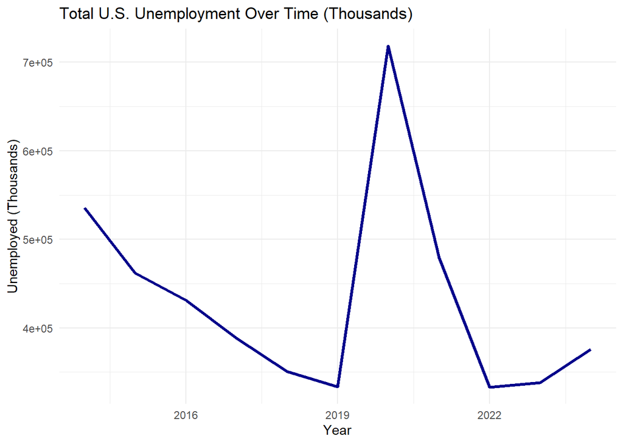

```r
### Total U.S. Unemployment Over Time
unemp_clean %>%
  group_by(year) %>%
  summarize(total_unemployed = sum(unemployment_thousands, na.rm = TRUE)) %>%
  ggplot(aes(year, total_unemployed)) +
  geom_line(color = "darkblue", size = 1.2) +
  labs(
    title = "Total U.S. Unemployment Over Time (Thousands)",
    x = "Year",
    y = "Unemployed (Thousands)"
  ) +
  theme_minimal()
```

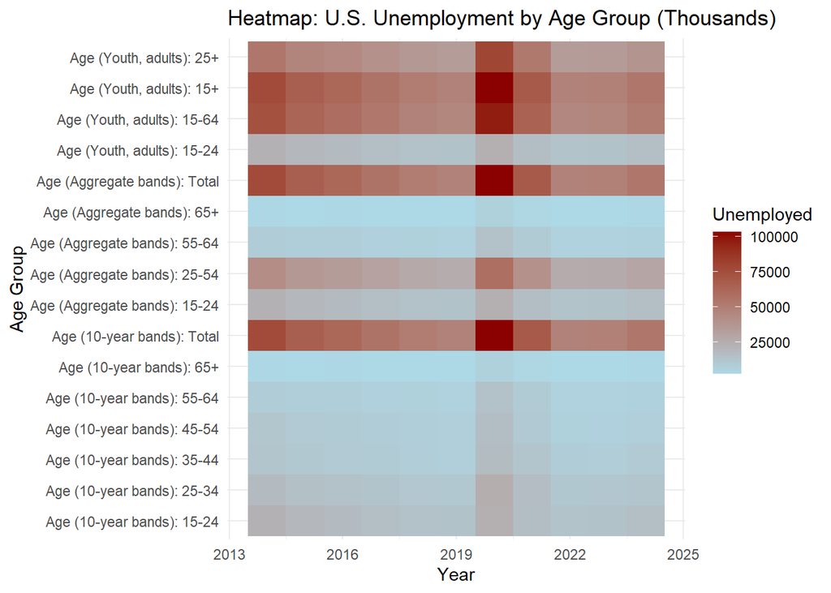

```r
### Heatmap of Unemployment by Age Group
unemp_clean %>%
  group_by(year, age_group) %>%
  summarize(total_unemployed = sum(unemployment_thousands, na.rm = TRUE), .groups = "drop") %>%
  ggplot(aes(x = year, y = age_group, fill = total_unemployed)) +
  geom_tile() +
  scale_fill_gradient(low = "lightblue", high = "darkred") +
  labs(
    title = "Heatmap: U.S. Unemployment by Age Group (Thousands)",
    x = "Year",
    y = "Age Group",
    fill = "Unemployed"
  ) +
  theme_minimal()
```

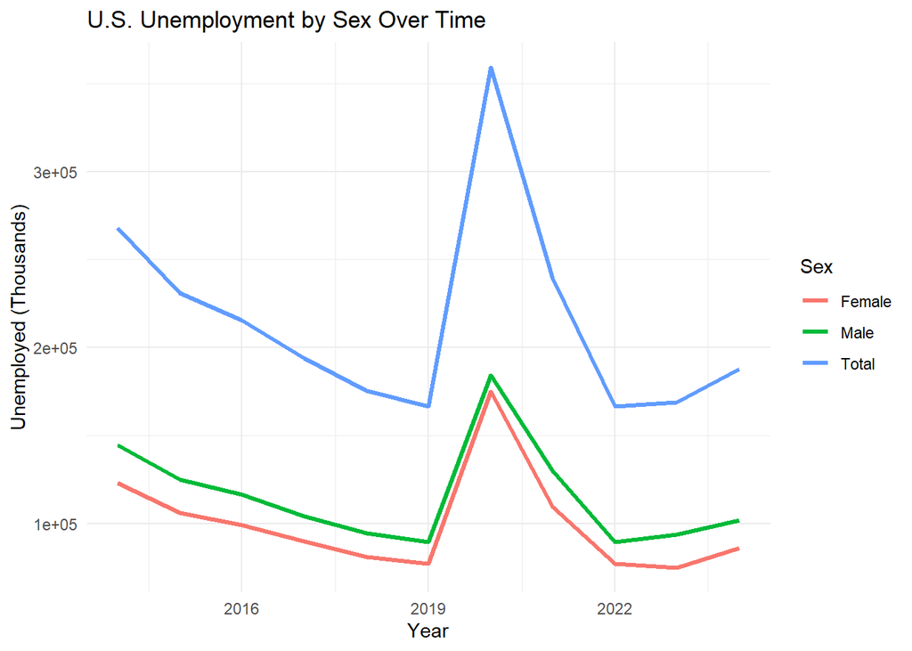

```r
### Unemployment by Sex Over Time
unemp_clean %>%
  group_by(year, sex) %>%
  summarize(total_unemployed = sum(unemployment_thousands, na.rm = TRUE)) %>%
  ggplot(aes(year, total_unemployed, color = sex)) +
  geom_line(size = 1.1) +
  labs(
    title = "U.S. Unemployment by Sex Over Time",
    x = "Year",
    y = "Unemployed (Thousands)",
    color = "Sex"
  ) +
  theme_minimal()
```